# ABUSO SEXUAL - ANÁLISIS ESTADÍSTICO DE DELITOS EN COLOMBIA

Centro Nacional Colombo Aleman SENA Sede TIC- Grupo TAD-7

Septiembre de 2024

# Delitos en Colombia

En este análisis estadístico, se examinan los 18 tipos de delitos reportados en Colombia desde el año 2018 hasta la fecha actual de Agosto de 2024, utilizando las bases de datos oficiales proporcionadas por la Policía Nacional. El estudio se enfoca en comparar las tasas de criminalidad a lo largo de diferentes periodos para evaluar las variaciones en la incidencia y distribución de cada delito bajo distintas administraciones.

Mediante un análisis descriptivo, se identifican tendencias y patrones criminales tanto a nivel nacional como específicamente en el municipio de Barranquilla y en todo el departamento del Atlántico. Los resultados obtenidos están destinados a informar a ciudadanos, empresas, entidades y servidores públicos, brindándoles una visión integral del comportamiento delictivo y facilitando la implementación de estrategias de prevención más efectivas. Así, el estudio contribuye a un entendimiento más profundo de los desafíos que enfrenta Colombia en términos de seguridad y justicia.

## Contexto del Estudio de delito sexual

En Colombia, la violencia sexual es un problema grave y persistente que afecta a diversas poblaciones. La información obtenida del sistema SIEDCO ha sido analizada para proporcionar una visión más clara sobre cómo varían los casos reportados en términos de género, edad, y ubicación geográfica. Este análisis es crucial para identificar áreas con mayores tasas de incidencia y para evaluar cómo las intervenciones y políticas actuales están influyendo en la reducción de estos delitos.

## Metodología

Los datos utilizados en este estudio se han extraído de la página oficial de la Policía Nacional de Colombia y abarcan el período de 2018 a agosto de 2024. Se han analizado varias dimensiones de los datos:

1. **Distribución por Género**: Se ha calculado la cantidad total de víctimas por género y se ha visualizado mediante un gráfico de pastel para mostrar la proporción de víctimas masculinas y femeninas.
2. **Distribución por Edad**: Se ha determinado la cantidad total de víctimas en diferentes rangos de edad, con gráficos de pastel que reflejan el porcentaje de víctimas en cada grupo etario.
3. **Tendencias Anuales**: Se ha analizado la cantidad de abusos reportados cada año para identificar tendencias a lo largo del tiempo, utilizando gráficos de líneas para representar las fluctuaciones anuales.
4. **Distribución Geográfica**: Se ha examinado la cantidad de reportes por departamento y municipio, con un enfoque especial en el Atlántico y Barranquilla. Gráficos de barras y pasteles ilustran la concentración de casos en las principales áreas.

# Análisis Nacional

En esta sección, se ofrece un análisis detallado de los reportes de abuso sexual a nivel nacional en Colombia. Este permite entender cómo han evolucionado las denuncias a lo largo de los años, desde 2018 hasta el mes de agosto del presente año 2024, y revela las tendencias generales que se han observado en todo el país.

```r
# Código para cargar librerías que procesarán los datos
library(readxl)
library(ggplot2)
library(dplyr)
library(tidyr)
library(stringr)
file_path <- "C:/Users/acer/Documents/DATA ANALYST/DAT_7/R/PROYECTO/BD_DELITOS/ABUSO_SEXUAL/Copia de BD_ABUSO_SEXUAL (version 1).xlsx"
df_abuso_sexual <- read_excel(file_path, sheet = "BD_ABUSO_SEXUAL")
```

## Tendencias Anuales

Este tipo de análisis permite identificar aumentos, disminuciones o estabilidad en las variables de interés con el paso del tiempo. En el contexto de los reportes de delitos o fenómenos sociales, la tendencia anual ayuda a entender si los casos tienden a incrementarse o disminuir cada año.

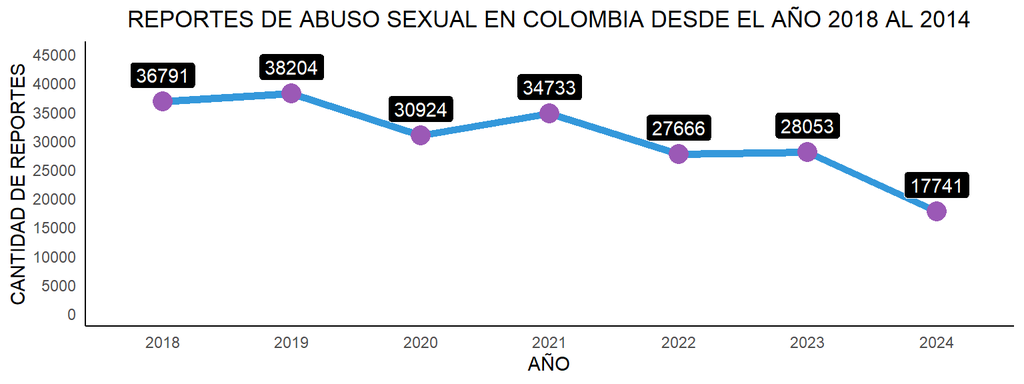

```r
# Convertir la columna AÑO a factor para que ggplot lo trate como variable categórica
df_abuso_sexual <- df_abuso_sexual %>%
  mutate(AÑO = as.factor(AÑO))

# Agrupar los datos por AÑO y sumar las cantidades para cada año
datos_año_abuso_sexual <- df_abuso_sexual %>%
  group_by(AÑO) %>%
  summarise(CANTIDAD_TOTAL = sum(CANTIDAD, na.rm = TRUE)) # Sumar ignorando valores NA en el campo AÑO

# Crear el gráfico de línea
suppressWarnings({ # Omitir advertencias innecesarias durante la ejecución
  ggplot(datos_año_abuso_sexual, aes(x = AÑO, y = CANTIDAD_TOTAL)) + # Define los datos y mapeos estéticos
    geom_line(aes(group = 1), color = "#3498db", size = 2) +  # Crea la línea que conecta los puntos con color azul y grosor de 2
    geom_point(color = "#9b59b6", size = 5) + # Añade puntos en cada año con color púrpura y tamaño 5
    geom_label(aes(label = CANTIDAD_TOTAL), # Añade etiquetas con los valores exactos encima de los puntos
               vjust = -0.5, # Ajustaa la posición vertical de las etiquetas
               hjust = 0.5, # Ajusta la posición horizontal de las etiquetas
               fill = "black",# Fondo negro para las etiquetas
               color = "white") + # Texto blanco para las etiquetas
    labs(title = "REPORTES DE ABUSO SEXUAL EN COLOMBIA DESDE EL AÑO 2018 AL 2014",  # Título del gráfico
         x = "AÑO", # Etiqueta para el eje X
         y = "CANTIDAD DE REPORTES") +  # Etiqueta para el eje Y
    scale_x_discrete(breaks = unique(datos_año_abuso_sexual$AÑO), # Asegura que todos los años aparezcan en el eje X
                     labels = unique(datos_año_abuso_sexual$AÑO)) +  # Etiquetas de los años en el eje X
    scale_y_continuous(limits = c(0, 45000),  # Ajusta el rango del eje Y
                       breaks = seq(0, 45000, by = 5000)) +  #Define los puntos de ruptura del eje Y cada 5000 unidades
    theme_minimal() + # Usar el tema 'minimal' para un diseño limpio y simple
    theme(
      plot.title = element_text(hjust = 0.5),# Centrar el título del gráfico
      panel.grid.major = element_blank(), # Elimina las líneas principales de la cuadrícula
      panel.grid.minor = element_blank(), # Elimina las líneas menores de la cuadrícula
      panel.border = element_blank(), # Elimina los bordes del panel
      axis.line = element_line(color = "black")  # Añade línea negra en los ejes X e Y
    )
})
```

En la presente grafica entre 2018 y 2024, los reportes de abuso sexual en Colombia muestran una tendencia general decreciente, con fluctuaciones en ciertos años. En 2018, se registraron 36,791 casos, cifra que aumentó ligeramente en 2019 a 38,204 casos. Sin embargo, en 2020, coincidiendo con la pandemia de COVID-19, los reportes disminuyeron significativamente a 30,924, lo que podría estar relacionado con las restricciones de movilidad y la reducción en el acceso a las instituciones para denunciar. Este patrón de fluctuación continuó en 2021 con un repunte a 34,733 casos, pero para 2022 los reportes cayeron nuevamente, llegando a 27,666.

En 2023, se observó una ligera recuperación de los reportes con 28,053 casos, aunque la cifra aún es menor en comparación con los años anteriores a la pandemia. El dato parcial de 2024 (hasta agosto) muestra una marcada reducción, con solo 17,741 reportes, lo que podría reflejar un cambio en los patrones de denuncia, cambios en la política pública o factores socioeconómicos aún por explorar. Esta tendencia a la baja podría ser un signo positivo, aunque también es crucial interpretar estos resultados con cautela, ya que podrían estar influenciados por la subnotificación de casos o cambios en las metodologías de recolección de datos.

## Departamentos de Colombia

En el siguiente gráfico se presenta un ranking de los 10 departamentos de Colombia con mayor cantidad de reportes de abuso sexual. Este análisis permite identificar las regiones donde se concentra el mayor número de casos, proporcionando una visión clara y comparativa de la magnitud de esta problemática en distintas zonas del país. Los departamentos están ordenados de mayor a menor, destacando aquellos con los reportes más altos para enfocar la atención en las áreas con mayores necesidades de intervención.

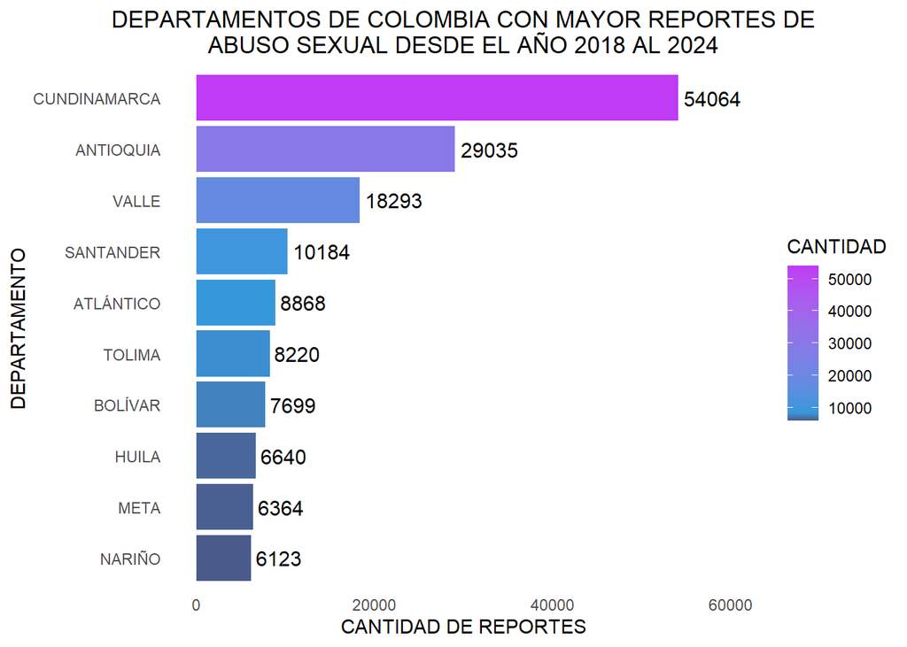

```r
# Agrupar por DEPARTAMENTO y sumar CANTIDAD
# Seleccionar los 10 departamentos con mayor cantidad de abusos
top_departamentos <- df_abuso_sexual %>%
  group_by(DEPARTAMENTO) %>%
  summarise(CANTIDAD_TOTAL = sum(CANTIDAD, na.rm = TRUE)) %>%
  arrange(desc(CANTIDAD_TOTAL)) %>%
  slice_max(order_by = CANTIDAD_TOTAL, n = 10)

titulo <- str_wrap("DEPARTAMENTOS DE COLOMBIA CON MAYOR REPORTES DE ABUSO SEXUAL DESDE EL AÑO 2018 AL 2024", width = 50) #Para ajustar el titulo

ggplot(top_departamentos, aes(x = reorder(DEPARTAMENTO, CANTIDAD_TOTAL), y = CANTIDAD_TOTAL, fill = CANTIDAD_TOTAL)) +
  geom_bar(stat = "identity") +  # Crear barras
  geom_text(aes(label = CANTIDAD_TOTAL),  # Etiquetas con las cantidades
            vjust = 0.5,  # Centrar verticalmente
            hjust = -0.1,  # Ajustar horizontalmente para que el texto no se salga
            color = "black",  # Color del texto
            size = 4, # Ajustar tamaño del texto
            nudge_x = 0) +  # Desplazar las etiquetas un poco hacia la derecha
    scale_fill_gradientn(colors = c("#4a5a8a", "#3498db", "#bf3bf4"),  # Colores personalizados
                       values = scales::rescale(c(min(top_departamentos$CANTIDAD_TOTAL),
                                                  median(top_departamentos$CANTIDAD_TOTAL),
                                                  max(top_departamentos$CANTIDAD_TOTAL)))) +  # Ajuste del rango
  coord_flip() +  # Girar el gráfico
  labs(title = titulo, # Usar el título ajustado
       x = "DEPARTAMENTO",
       y = "CANTIDAD DE REPORTES",
       fill = "CANTIDAD") +  # Etiqueta de la leyenda

  scale_y_continuous(limits = c(0, 60000),  # Configurar el rango del eje Y
                       breaks = seq(0, 60000, by = 20000)) +  # Definir los puntos de ruptura del eje Y
  theme_minimal() +  # Usar un tema limpio
  theme(
    plot.title = element_text(hjust = 0.5),  # Centrar el título
    panel.grid.major = element_blank(),  # Eliminar líneas mayores de la cuadrícula
    panel.grid.minor = element_blank(),  # Eliminar líneas menores de la cuadrícula
    panel.border = element_blank(),  # Eliminar borde del panel
  )
```

Entre los departamentos más destacados, Cundinamarca encabeza la lista con un número considerablemente mayor de reportes, seguido por Antioquia y Valle. Estos tres departamentos reflejan una alta concentración de casos en comparación con el resto. Santander y Atlántico también tienen un número significativo de reportes, pero en menor proporción que los primeros.

La diferencia en la cantidad de reportes entre los departamentos es notable, lo que refleja el contraste en la incidencia del problema en diferentes partes del territorio colombiano.

Es importante resaltar que la población en dichas regiones varía considerablemente, lo que puede influir en la cantidad de reportes de abuso sexual. Los departamentos más poblados, como Cundinamarca, Antioquia y Valle, tienden a registrar un mayor número de casos, lo que podría estar relacionado tanto con su densidad poblacional como con la capacidad de reportar y registrar estos incidentes. Sin embargo, esto no significa necesariamente que en departamentos con menos reportes el problema sea menos grave, sino que puede haber factores como el acceso limitado a sistemas de denuncia o la falta de visibilidad que impacten en los registros oficiales.

## Distribución por Género

En esta sección en el análisis estadístico de delitos sexuales examina la proporción de víctimas de abuso sexual desglosada por género. Esta visualización tiene como objetivo proporcionar una comprensión clara de cómo se distribuyen las víctimas según dicha categoría.

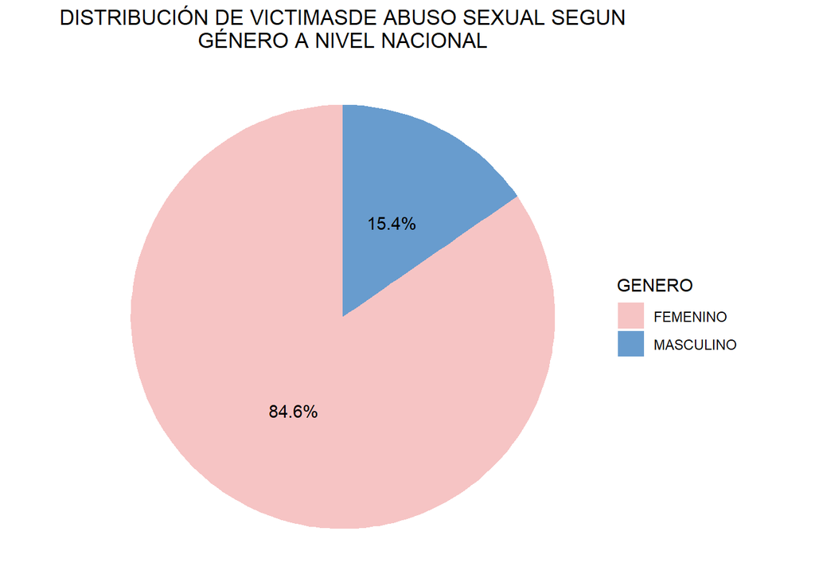

A través de un gráfico de pastel, se ilustra que el 84,6% de las víctimas de abuso sexual son mujeres, mientras que el 15,4% restante corresponde a hombres. Este análisis revela una notable desigualdad en la incidencia del abuso sexual entre los géneros, con una prevalencia significativamente mayor entre las mujeres. Este hallazgo es crucial para identificar y abordar las necesidades específicas de las víctimas, y para desarrollar estrategias de prevención y apoyo que se adapten a las realidades de cada género. La alta proporción de víctimas femeninas destaca la necesidad de implementar medidas focalizadas en la protección y apoyo a mujeres, al tiempo que se considera el apoyo necesario para los hombres afectados por el abuso sexual.

## Distribución por Edad

Se analiza la prevalencia de abuso sexual entre diferentes rangos etarios, utilizando un gráfico de pastel para representar visualmente los datos. Esta gráfica muestra cómo se distribuyen las víctimas de abuso sexual según sus grupos de edad:

- Menores: entre 0 años a 12 años
- Adolescentes: entre 13 años y 17 años
- Adultos: 18 años en adelante

Agrupación referente a la clasificación del código de infancia y adolescencia ley 1098 de del 8 de noviembre de 2006, en su artículo 3.

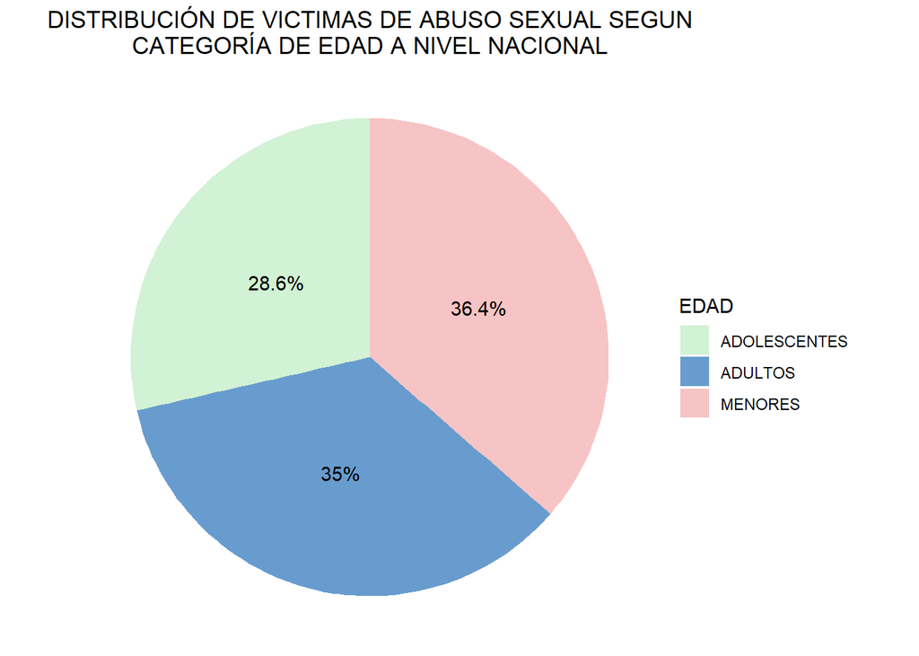

```r
# Gráfico de pastel para distribución por edad
datos_edad_abuso_sexual <- df_abuso_sexual %>%
  filter(EDAD != "N/D") %>%
  group_by(EDAD) %>%
  summarise(CANTIDAD_TOTAL = sum(CANTIDAD), .groups = 'drop') %>%
  mutate(PORCENTAJE = CANTIDAD_TOTAL / sum(CANTIDAD_TOTAL) * 100)

titulo <- str_wrap("DISTRIBUCIÓN DE VICTIMAS DE ABUSO SEXUAL SEGUN CATEGORÍA DE EDAD A NIVEL NACIONAL",width = 50)

# Crear el gráfico de pastel con porcentaje
ggplot(datos_edad_abuso_sexual, aes(x = "", y = CANTIDAD_TOTAL, fill = EDAD)) +
  geom_bar(stat = "identity", width = 1) +
  coord_polar("y", start = 0) +
  labs(title = titulo) +
  theme_void() +
  scale_fill_manual(values = c("#D1F2D4", "#689cce", "#F6C4C4")) +
  geom_text(aes(label = paste0(round(PORCENTAJE, 1), "%")),
            position = position_stack(vjust = 0.5)) +
  theme(plot.title = element_text(hjust = 0.5))
```

El análisis revela que la distribución de las víctimas de abuso sexual se distribuye de la siguiente manera: menores de edad representan el 36,4% de las víctimas, adultos constituyen el 35%, y adolescentes conforman el 28,6%. Estos datos destacan una prevalencia significativa del abuso sexual en menores de edad, seguidos de cerca por adultos y adolescentes

# Análisis del Atlántico

Se procederá a realizar un análisis de la tendencia anual y la distribución de reportes de abuso sexual en los municipios del departamento del Atlántico. Este análisis permitirá identificar patrones de aumento o disminución en los casos reportados a lo largo del tiempo, así como destacar los municipios con mayor incidencia. Además, se generarán gráficos que desglosan los reportes por género y edad, enfocándose específicamente en el nivel del departamento. Estos gráficos proporcionarán una visión clara de las características demográficas de las víctimas en el Departamento del Atlántico.

## Tendencias Anuales

En el contexto del Departamento del Atlántico, este análisis ayuda a identificar patrones significativos en la frecuencia de los reportes de abuso sexual desde 2018 hasta agosto de 2024. Observar las tendencias anuales permite comprender si el número de reportes ha aumentado, disminuido o permanecido estable con el tiempo. Esto es fundamental para evaluar la efectividad de las políticas y programas de prevención y respuesta, y para identificar posibles áreas de intervención. El gráfico de líneas resultante ofrece una visualización clara de estas variaciones, mostrando las fluctuaciones en el número total de reportes anuales y proporcionando información valiosa para la toma de decisiones y la planificación de estrategias de apoyo a las víctimas.

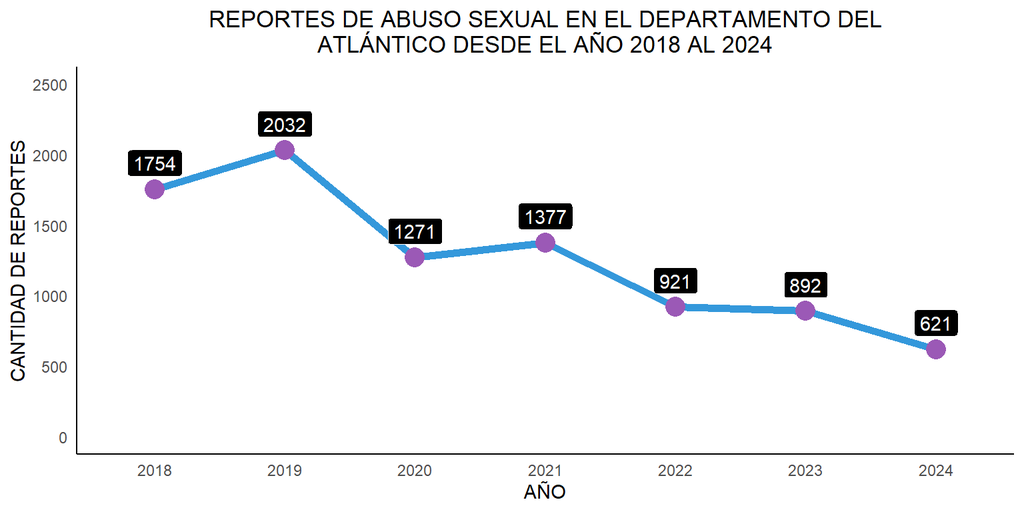

```r
# Filtrar los datos para el departamento del Atlántico
df_abuso_sexual_atlantico <- df_abuso_sexual %>%
  filter(DEPARTAMENTO == "ATLÁNTICO") %>% # Filtrar los datos para el Atlántico
  mutate(AÑO = as.factor(AÑO)) # Convertir la columna AÑO a factor para tratarla como variable categórica

# Agrupar los datos por AÑO y sumar las cantidades para cada año
datos_año_abuso_sexual_atlantico <- df_abuso_sexual_atlantico %>%
  group_by(AÑO) %>%
  summarise(CANTIDAD_TOTAL = sum(CANTIDAD, na.rm = TRUE)) # Sumar ignorando valores NA en el campo CANTIDAD

titulo <- str_wrap("REPORTES DE ABUSO SEXUAL EN EL DEPARTAMENTO DEL ATLÁNTICO DESDE EL AÑO 2018 AL 2024", width = 50)

# Crear el gráfico de línea
suppressWarnings({ # Omitir advertencias innecesarias durante la ejecución
  ggplot(datos_año_abuso_sexual_atlantico, aes(x = AÑO, y = CANTIDAD_TOTAL)) + # Define los datos y mapeos estéticos
    geom_line(aes(group = 1), color = "#3498db", size = 2) +  # Crea la línea que conecta los puntos con color azul y grosor de 2
    geom_point(color = "#9b59b6", size = 5) + # Añade puntos en cada año con color púrpura y tamaño 5
    geom_label(aes(label = CANTIDAD_TOTAL), # Añade etiquetas con los valores exactos encima de los puntos
               vjust = -0.5, # Ajusta la posición vertical de las etiquetas
               hjust = 0.5, # Ajusta la posición horizontal de las etiquetas
               fill = "black", # Fondo negro para las etiquetas
               color = "white") + # Texto blanco para las etiquetas
    labs(title = titulo,  # Título del gráfico
         x = "AÑO", # Etiqueta para el eje X
         y = "CANTIDAD DE REPORTES") +  # Etiqueta para el eje Y
    scale_x_discrete(breaks = unique(datos_año_abuso_sexual_atlantico$AÑO), # Asegura que todos los años aparezcan en el eje X
                     labels = unique(datos_año_abuso_sexual_atlantico$AÑO)) + # Etiquetas de los años en el eje X
    scale_y_continuous(limits = c(0, 2500),  # Ajusta el rango del eje Y
                       breaks = seq(0, 2500, by = 500)) + # Define los puntos de ruptura del eje Y cada 500 unidades
    theme_minimal() + # Usar el tema 'minimal' para un diseño limpio y simple
    theme(
      plot.title = element_text(hjust = 0.5), # Centrar el título del gráfico
      panel.grid.major = element_blank(), # Elimina las líneas principales de la cuadrícula
      panel.grid.minor = element_blank(), # Elimina las líneas menores de la cuadrícula
      panel.border = element_blank(), # Elimina los bordes del panel
      axis.line = element_line(color = "black") # Añade línea negra en los ejes X e Y
    )
})
```

El análisis de las tendencias anuales en los reportes de abuso sexual en el Departamento del Atlántico revela fluctuaciones significativas en la cantidad de casos reportados entre 2018 y 2024. En 2018, se registraron 1,754 reportes, cifra que aumentó a 2,032 en 2019, indicando un incremento en los reportes durante ese año. Sin embargo, a partir de 2020, se observó una disminución progresiva, con un descenso notable a 1,271 reportes en 2020 y una ligera recuperación a 1,377 en 2021. En 2022, los reportes cayeron a 921, y esta tendencia a la baja continuó en 2023 con 892 reportes. En 2024, hasta agosto, se registraron 621 casos, lo que sugiere una disminución continua en comparación con los años anteriores. Estas variaciones podrían reflejar una combinación de factores, incluyendo cambios en la capacidad de reporte, la eficacia de las políticas de prevención, y posibles variaciones en la conciencia y disposición de las víctimas a denunciar. El análisis subraya la importancia de monitorear continuamente estas tendencias para adaptar las estrategias de intervención y garantizar una respuesta efectiva a los casos de abuso sexual en la región

## Municipios del Atlántico

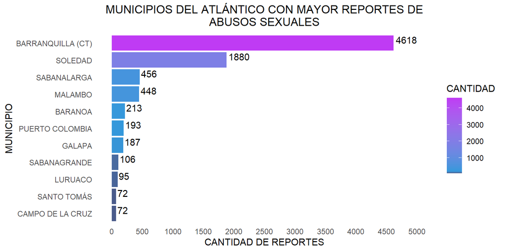

```r
# Filtrar datos para el Departamento del Atlántico
df_abuso_sexual_atlantico <- df_abuso_sexual %>%
  filter(DEPARTAMENTO == "ATLÁNTICO") %>%  # Filtrar por el departamento del Atlántico
  group_by(MUNICIPIO) %>%  # Agrupar por municipio
  summarise(CANTIDAD_TOTAL = sum(CANTIDAD, na.rm = TRUE)) %>%  # Sumar la cantidad total de abusos por municipio
  arrange(desc(CANTIDAD_TOTAL)) %>%  # Ordenar en orden descendente
  slice_max(order_by = CANTIDAD_TOTAL, n = 10)  # Seleccionar los 5 municipios con mayor cantidad

titulo <- str_wrap("MUNICIPIOS DEL ATLÁNTICO CON MAYOR REPORTES DE ABUSOS SEXUALES", width=50)

# Crear gráfico de barras
suppressWarnings({ # Omitir advertencias innecesarias durante la ejecución
  ggplot(df_abuso_sexual_atlantico, aes(x = reorder(MUNICIPIO, CANTIDAD_TOTAL), y = CANTIDAD_TOTAL, fill = CANTIDAD_TOTAL)) +
    geom_bar(stat = "identity") +  # Crear barras
    geom_text(aes(label = CANTIDAD_TOTAL),  # Etiquetas con las cantidades
              vjust = 0.5,  # Ajustar verticalmente para centrar en la barra
              hjust = -0.1,  # Ajustar horizontalmente para que el texto quede al lado de la barra
              color = "black",  # Color del texto
              nudge_x = 0.2) +  # Desplazar el texto un poco hacia la derecha
    scale_fill_gradientn(colors = c("#4a5a8a", "#3498db", "#bf3bf4"),  # Colores personalizados
                       values = scales::rescale(c(min(df_abuso_sexual_atlantico$CANTIDAD_TOTAL),
                                                  median(df_abuso_sexual_atlantico$CANTIDAD_TOTAL),
                                                  max(df_abuso_sexual_atlantico$CANTIDAD_TOTAL)))) +  # Ajuste del rango
    coord_flip() +  # Girar el gráfico para una mejor legibilidad
    labs(title = titulo,
         x = "MUNICIPIO",
         y = "CANTIDAD DE REPORTES",
        fill = "CANTIDAD") +  # Etiqueta de la leyenda
    scale_y_continuous(limits = c(0, 5000),  # Configurar el rango del eje Y
                       breaks = seq(0, 5000, by = 500)) +  # Definir los puntos de ruptura del eje Y
    theme_minimal()+ # Usar un tema limpio para una mejor presentación
    theme(
      plot.title = element_text(hjust = 0.5),  # Centrar el título
      panel.grid.major = element_blank(),  # Eliminar las líneas de cuadrícula mayores
      panel.grid.minor = element_blank(),  # Eliminar las líneas de cuadrícula menores
      panel.border = element_blank(),  # Eliminar el borde del panel
    )
})
```

## Distribucón por Género

Este análisis permite identificar qué género está más afectado por el abuso sexual en la región. A su vez, evaluar la distribución de víctimas por género también permite monitorear las tendencias a lo largo del tiempo y medir la efectividad de las intervenciones implementadas.

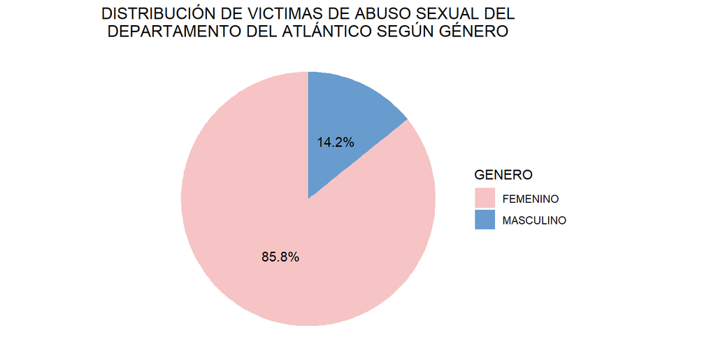

```r
# Filtrar los datos para el departamento del Atlántico
df_abuso_sexual_atlantico <- df_abuso_sexual %>%
  filter(DEPARTAMENTO == "ATLÁNTICO")
# Filtrar los datos para eliminar "N/D"
datos_filtrados_genero_atlantico <- df_abuso_sexual_atlantico %>% filter(GENERO != "N/D")
# Calcular la cantidad de víctimas por género
datos_genero_abuso_sexual_atlantico <- datos_filtrados_genero_atlantico %>%
  group_by(GENERO) %>%
  summarise(CANTIDAD_TOTAL = sum(CANTIDAD), .groups = 'drop')
# Calcular el porcentaje
datos_genero_abuso_sexual_atlantico <- datos_genero_abuso_sexual_atlantico %>%
  mutate(PORCENTAJE = CANTIDAD_TOTAL / sum(CANTIDAD_TOTAL) * 100)


# Crear el gráfico de pastel con porcentaje

titulo <- str_wrap("DISTRIBUCIÓN DE VICTIMAS DE ABUSO SEXUAL DEL DEPARTAMENTO DEL ATLÁNTICO SEGÚN GÉNERO",width = 50)

suppressWarnings({ # Omitir advertencias innecesarias durante la ejecución
  ggplot(datos_genero_abuso_sexual_atlantico, aes(x = "", y = CANTIDAD_TOTAL, fill = GENERO)) +
    geom_bar(stat = "identity", width = 1) + # Crear el gráfico de barras
    coord_polar("y", start = 0) + # Convertir el gráfico de barras en un gráfico de pastel
    labs(title = titulo) + # Título del gráfico
    theme_void() +  # Eliminar fondo y ejes
    scale_fill_manual(values = c("#F6C4C4", "#689cce")) +  # Colores para los géneros
    geom_text(aes(label = paste0(round(PORCENTAJE, 1), "%")), # Mostrar los porcentajes en el gráfico
              position = position_stack(vjust = 0.5)) +  # Ajustar la posición del texto
    theme(plot.title = element_text(hjust = 0.5))  # Centrar el título
})
```

En el análisis de la distribución de víctimas de abuso sexual en el Departamento del Atlántico, se observa una notable predominancia del género femenino, que representa el 85.8% del total de los casos reportados. Esta cifra refleja una alta incidencia de abuso sexual entre mujeres en comparación con el género masculino. El porcentaje restante, que corresponde al 14.2%, está compuesto por víctimas masculinas. A su vez, se refleja que el departamento del atlántico sigue la tendencia que se refleja a nivel nacional previamente mencionado.

## Distribucíon por Edad

El análisis de la distribución de víctimas de abuso sexual en el Departamento del Atlántico según la edad proporciona información crucial para entender el perfil demográfico de las personas afectadas. Este análisis revela que la distribución de víctimas varía entre los diferentes grupos etarios, permitiendo identificar las edades más vulnerables y adaptar las estrategias de prevención y apoyo en consecuencia.

- Menores: entre 0 años a 12 años
- Adolescentes: entre 13 años y 17 años
- Adultos: 18 años en adelante

Agrupación referente a la clasificación del código de infancia y adolescencia ley 1098 de del 8 de noviembre de 2006, en su artículo 3.

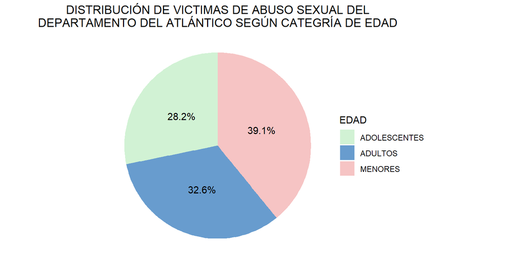

```r
df_abuso_sexual_atlantico <- df_abuso_sexual %>%
  filter(DEPARTAMENTO == "ATLÁNTICO")
# Filtrar datos para excluir las filas donde EDAD es "N/D"
datos_filtrados_edad_atlantico <- df_abuso_sexual_atlantico %>% filter(EDAD != "N/D")

# Calcular la cantidad de víctimas por edad
datos_edad_abuso_sexual_atlantico <- datos_filtrados_edad_atlantico %>%
  group_by(EDAD) %>%
  summarise(CANTIDAD_TOTAL = sum(CANTIDAD), .groups = 'drop')

# Calcular el porcentaje
datos_edad_abuso_sexual_atlantico <- datos_edad_abuso_sexual_atlantico %>%
  mutate(PORCENTAJE = CANTIDAD_TOTAL / sum(CANTIDAD_TOTAL) * 100)

titulo <- str_wrap("DISTRIBUCIÓN DE VICTIMAS DE ABUSO SEXUAL DEL DEPARTAMENTO DEL ATLÁNTICO SEGÚN CATEGRÍA DE EDAD",width = 50)

# Crear el gráfico de pastel con porcentaje
suppressWarnings({ # Omitir advertencias innecesarias durante la ejecución
  ggplot(datos_edad_abuso_sexual_atlantico, aes(x = "", y = CANTIDAD_TOTAL, fill = EDAD)) +
    geom_bar(stat = "identity", width = 1) +  # Crear barras de tamaño 1 para gráfico de pastel
    coord_polar("y", start = 0) +  # Convertir el gráfico de barras en un gráfico de pastel
    labs(title = titulo) +  # Título del gráfico
    theme_void() +  # Eliminar fondo y ejes
    scale_fill_manual(values = c("#D1F2D4", "#689cce", "#F6C4C4")) +  # Especificar colores
    geom_text(aes(label = paste0(round(PORCENTAJE, 1), "%")),  # Etiquetas con porcentajes
              position = position_stack(vjust = 0.5)) +
    theme(plot.title = element_text(hjust = 0.5))  # Centrar el título
})
```

Los resultados del análisis de la distribución de víctimas de abuso sexual en el Departamento del Atlántico muestran una tendencia que es notablemente similar a la tendencia nacional. En el Atlántico, el 39,1% de las víctimas son menores de edad, un porcentaje que es ligeramente superior al 36,4% observado a nivel nacional. Los adolescentes representan el 28,2% de las víctimas en el Atlántico, lo que es muy comparable al 28,6% a nivel nacional. Por último, los adultos constituyen el 32,6% de las víctimas en el Atlántico, cifra que se asemeja al 35% a nivel nacional.

Esta similitud en los datos entre el Atlántico y el promedio nacional sugiere que las tendencias de abuso sexual en cuanto a edad son consistentes en ambas escalas. Sin embargo, la ligera diferencia en los porcentajes puede reflejar particularidades locales que podrían requerir un enfoque adaptado en las estrategias de prevención y apoyo. La alta proporción de víctimas menores de edad en el Atlántico, superior a la media nacional, podría indicar una mayor vulnerabilidad en esta franja etaria y subraya la importancia de reforzar las medidas de protección y los programas de concienciación dirigidos a la población juvenil.

# Análisis de Barranquilla

En el análisis específico para Barranquilla, se evalua la tendencia anual de los reportes de abuso sexual en esta ciudad. Se identificará el patrón de los casos a lo largo del tiempo. Adicionalmente, se presentarán gráficos que muestran la distribución de los casos por género y edad, centrados exclusivamente en esta ciudad.

## Tendencias Anuales

En esta sección, se presentarán las tendencias anuales de reportes de abuso sexual en Barranquilla, con el fin de identificar cómo ha variado la cantidad de denuncias a lo largo de los años. Este análisis permite observar si existen picos o caídas significativas en ciertos periodos.

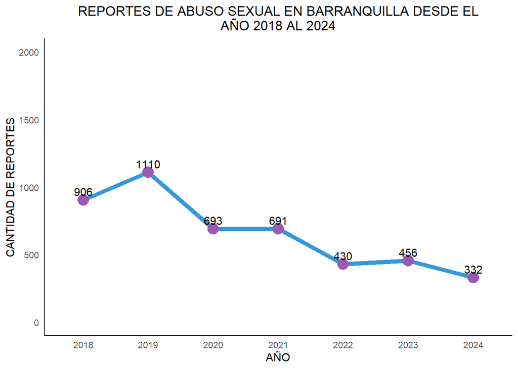

```r
# Filtrar los datos para la ciudad de Barranquilla
df_abuso_sexual_bq <- df_abuso_sexual %>%
  filter(MUNICIPIO == "BARRANQUILLA (CT)") %>% # Filtrar los datos para Barranquilla
  mutate(AÑO = as.factor(AÑO)) # Convertir la columna AÑO a factor para tratarla como variable categórica

# Agrupar los datos por AÑO y sumar las cantidades para cada año
df_abuso_sexual_bq_año <- df_abuso_sexual_bq %>%
  group_by(AÑO) %>%
  summarise(CANTIDAD_TOTAL = sum(CANTIDAD, na.rm = TRUE)) # Sumar ignorando valores NA en el campo CANTIDAD

titulo <- str_wrap("REPORTES DE ABUSO SEXUAL EN BARRANQUILLA DESDE EL AÑO 2018 AL 2024", width = 50)

# Crear el gráfico de línea
suppressWarnings({ # Omitir advertencias innecesarias durante la ejecución
  ggplot(df_abuso_sexual_bq_año, aes(x = AÑO, y = CANTIDAD_TOTAL)) + # Define los datos y mapeos estéticos
    geom_line(aes(group = 1), color = "#3498db", size = 2) +  # Crea la línea que conecta los puntos con color azul y grosor de 2
    geom_point(color = "#9b59b6", size = 5) + # Añade puntos en cada año con color púrpura y tamaño 5
    geom_text(aes(label = CANTIDAD_TOTAL), # Añade etiquetas con los valores exactos encima de los puntos
              vjust = -0.5, # Ajusta la posición vertical de las etiquetas
              hjust = 0.5, # Ajusta la posición horizontal de las etiquetas
              color = "black") + # Texto negro para las etiquetas
    labs(title = titulo,  # Título del gráfico
         x = "AÑO", # Etiqueta para el eje X
         y = "CANTIDAD DE REPORTES") +  # Etiqueta para el eje Y
    scale_x_discrete(breaks = unique(df_abuso_sexual_bq_año$AÑO), # Asegura que todos los años aparezcan en el eje X
                     labels = unique(df_abuso_sexual_bq_año$AÑO)) + # Etiquetas de los años en el eje X
    scale_y_continuous(limits = c(0, 2000),  # Ajusta el rango del eje Y de 0 a 2000
                       breaks = seq(0, 2000, by = 500)) + # Define los puntos de ruptura del eje Y de 500 en 500
    theme_minimal() + # Usar el tema 'minimal' para un diseño limpio y simple
    theme(
      plot.title = element_text(hjust = 0.5), # Centrar el título del gráfico
      panel.grid.major = element_blank(), # Elimina las líneas principales de la cuadrícula
      panel.grid.minor = element_blank(), # Elimina las líneas menores de la cuadrícula
      panel.border = element_blank(), # Elimina los bordes del panel
      axis.line = element_line(color = "black") # Añade línea negra en los ejes X e Y
    )
})
```

## Distribución por Género

La distribución por género en Barranquilla muestra cómo se dividen los reportes de abuso sexual entre hombres y mujeres. Esta información es crucial para entender las dinámicas de violencia sexual en la ciudad. La categorización por género incluye tanto a víctimas femeninas como masculinas, lo que facilita una visión más amplia del fenómeno en esta localidad.

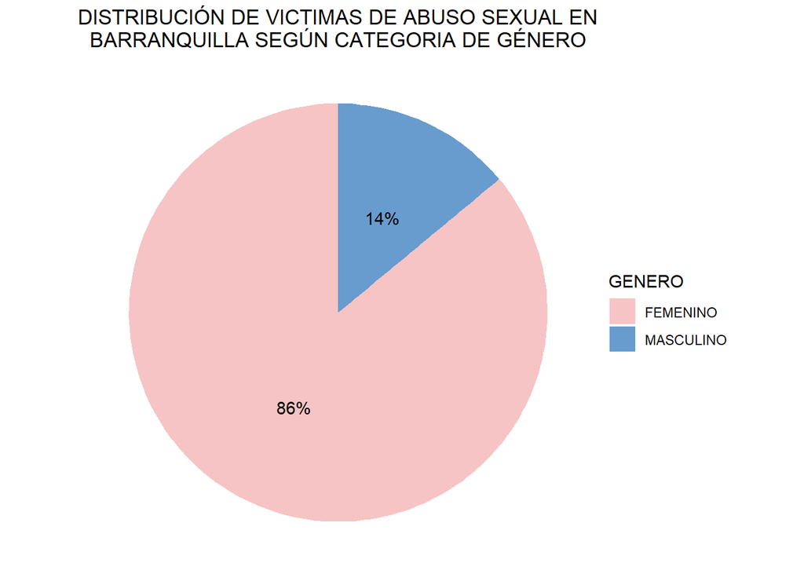

```r
# Filtrar los datos para la ciudad de Barranquilla
df_abuso_sexual_barranquilla <- df_abuso_sexual %>%
  filter(MUNICIPIO == "BARRANQUILLA (CT)")

# Filtrar datos para excluir las filas donde GENERO es "N/D"
datos_filtrados_genero_bq <- df_abuso_sexual_barranquilla %>% filter(GENERO != "N/D")
# Calcular la cantidad de víctimas por genero
datos_genero_bq <- datos_filtrados_genero_bq %>%
  group_by(GENERO) %>%
  summarise(CANTIDAD_TOTAL = sum(CANTIDAD), .groups = 'drop')
# Calcular el porcentaje
datos_genero_bq <- datos_genero_bq %>%
  mutate(PORCENTAJE = CANTIDAD_TOTAL / sum(CANTIDAD_TOTAL) * 100)

titulo <- str_wrap("DISTRIBUCIÓN DE VICTIMAS DE ABUSO SEXUAL EN BARRANQUILLA SEGÚN CATEGORIA DE GÉNERO", width=50)

# Crear el gráfico de pastel con porcentaje
suppressWarnings({ # Omitir advertencias innecesarias durante la ejecución
  ggplot(datos_genero_bq, aes(x = "", y = CANTIDAD_TOTAL, fill = GENERO)) +  # Paréntesis de cierre añadido aquí
    geom_bar(stat = "identity", width = 1) +  # Crear barras de tamaño 1 para gráfico de pastel
    coord_polar("y", start = 0) +  # Convertir el gráfico de barras en un gráfico de pastel
    labs(title = titulo) +  # Título del gráfico
    theme_void() +  # Eliminar fondo y ejes
    scale_fill_manual(values = c("#F6C4C4", "#689cce")) +  # Especificar colores
    geom_text(aes(label = paste0(round(PORCENTAJE, 1), "%")),  # Etiquetas con porcentajes
              position = position_stack(vjust = 0.5)) +
    theme(plot.title = element_text(hjust = 0.5))  # Centrar el título
})
```

## Distribución por Edad

La Distribución por Edad es un análisis que permite observar cómo se distribuyen ciertos eventos o fenómenos, en este caso, los reportes de abuso sexual, entre diferentes grupos de edad en la ciudad de Barranquilla.

- Menores: entre 0 años a 12 años
- Adolescentes: entre 13 años y 17 años
- Adultos: 18 años en adelante

Agrupación referente a la clasificación del código de infancia y adolescencia ley 1098 de del 8 de noviembre de 2006, en su artículo 3.

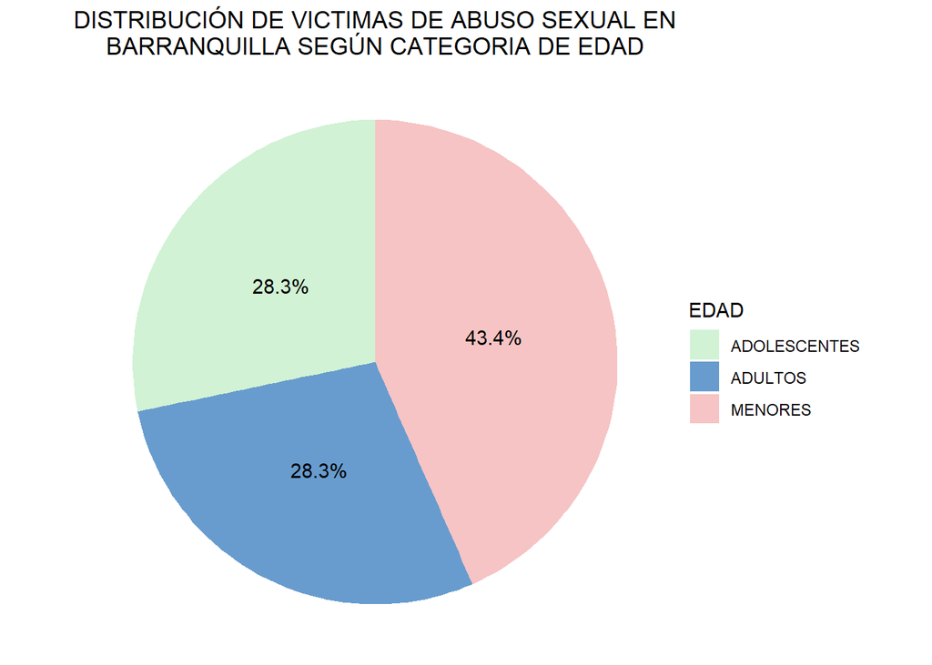

```r
# Filtrar los datos para la ciudad de Barranquilla
df_abuso_sexual_barranquilla <- df_abuso_sexual %>%
  filter(MUNICIPIO == "BARRANQUILLA (CT)")
# Filtrar datos para excluir las filas donde EDAD es "N/D"
datos_filtrados_edad_barranquilla <- df_abuso_sexual_barranquilla %>% filter(EDAD != "N/D")
# Calcular la cantidad de víctimas por edad
datos_edad_abuso_sexual_barranquilla <- datos_filtrados_edad_barranquilla %>%
  group_by(EDAD) %>%
  summarise(CANTIDAD_TOTAL = sum(CANTIDAD), .groups = 'drop')
# Calcular el porcentaje
datos_edad_abuso_sexual_barranquilla <- datos_edad_abuso_sexual_barranquilla %>%
  mutate(PORCENTAJE = CANTIDAD_TOTAL / sum(CANTIDAD_TOTAL) * 100)

titulo <- str_wrap("DISTRIBUCIÓN DE VICTIMAS DE ABUSO SEXUAL EN BARRANQUILLA SEGÚN CATEGORIA DE EDAD", width=50)
# Crear el gráfico de pastel con porcentaje
ggplot(datos_edad_abuso_sexual_barranquilla, aes(x = "", y = CANTIDAD_TOTAL, fill = EDAD)) +
  geom_bar(stat = "identity", width = 1) +  # Crear barras de tamaño 1 para gráfico de pastel
  coord_polar("y", start = 0) +  # Convertir el gráfico de barras en un gráfico de pastel
  labs(title = titulo) +  # Título del gráfico
  theme_void() +  # Eliminar fondo y ejes
  scale_fill_manual(values = c("#D1F2D4", "#689cce", "#F6C4C4")) +  # Especificar colores
  geom_text(aes(label = paste0(round(PORCENTAJE, 1), "%")),  # Etiquetas con porcentajes
            position = position_stack(vjust = 0.5)) +
  theme(plot.title = element_text(hjust = 0.5))  # Centrar el título
```

En Barranquilla, la distribución por edad de los reportes de abuso sexual muestra que el 43,4% de las víctimas son menores de edad, el 28,3% son adolescentes y el 28,3% son adultos. Este perfil revela que una proporción significativa de las víctimas son menores, destacándose por encima de los adolescentes y adultos. Comparado con las tendencias nacionales, donde el 36,4% de las víctimas son menores, el 28,6% adolescentes y el 35% adultos.

Barranquilla presenta una mayor incidencia en menores de edad, mientras que la proporción de adultos es menor que la media nacional y del departamento.

Este análisis destaca la necesidad de enfocarse especialmente en la protección y apoyo a los menores en Barranquilla, dado su elevado porcentaje en comparación con otros contextos.

# Conclusión

El análisis de las estadísticas delictivas proporciona una comprensión integral de los delitos sexuales en Colombia. A través de los gráficos presentados, se pueden observar patrones y tendencias que son esenciales para la formulación de estrategias efectivas de prevención y respuesta. Los resultados destacan áreas críticas que requieren atención y proporcionan una base para futuras investigaciones y políticas.

En el Departamento del Atlántico, los datos muestran un aumento general en los reportes hasta 2019, seguido de una disminución significativa en los años siguientes. En 2022 y 2023, se observó una caída notable en el número de reportes, lo que podría indicar un cambio en la dinámica de reporte o una posible reducción en la incidencia de abusos. La tendencia descendente en los últimos años podría ser reflejo de varios factores, incluyendo posibles barreras para la denuncia o cambios en el entorno social y político que afectan la visibilidad de los abusos sexuales. Un análisis más detallado de las causas subyacentes es crucial para abordar estas tendencias de manera efectiva.

# Referencias

Policía Nacional de Colombia. [Acceso a Datos Estadísticos](https://www.policia.gov.co/estadistica-delictiva?page=1).